# 1. Problem Statement

### **Create a machine learning model which predicts the price of Diamond using a dataset containing multiple values along with its price.**

# 2. Data Collection

### **The Dataset was downloaded from kaggle.com**

### link : https://www.kaggle.com/datasets/amirhosseinmirzaie/diamonds-price-dataset

# 3. Importing and understanding the dataset

```python
# importing required libraries

import numpy as np
import pandas as pd
import matplotlib.pyplot as plt
import sklearn
from sklearn.preprocessing import LabelEncoder
from sklearn.model_selection import train_test_split
from sklearn.metrics import r2_score
from sklearn.metrics import mean_squared_error
from sklearn.metrics import mean_absolute_error

from sklearn.linear_model import LinearRegression
from sklearn.preprocessing import PolynomialFeatures
from sklearn.neighbors import KNeighborsRegressor
from sklearn.tree import DecisionTreeRegressor
from sklearn.ensemble import RandomForestRegressor
```

```python
# importing dataset and storing it in a dataframe

a = pd.read_csv("diamonds.csv")
a
```

|  | carat | cut | color | clarity | depth | table | price | x | y | z |
| --- | --- | --- | --- | --- | --- | --- | --- | --- | --- | --- |
| 0 | 0.23 | Ideal | E | SI2 | 61.5 | 55.0 | 326 | 3.95 | 3.98 | 2.43 |
| 1 | 0.21 | Premium | E | SI1 | 59.8 | 61.0 | 326 | 3.89 | 3.84 | 2.31 |
| 2 | 0.23 | Good | E | VS1 | 56.9 | 65.0 | 327 | 4.05 | 4.07 | 2.31 |
| 3 | 0.29 | Premium | I | VS2 | 62.4 | 58.0 | 334 | 4.20 | 4.23 | 2.63 |
| 4 | 0.31 | Good | J | SI2 | 63.3 | 58.0 | 335 | 4.34 | 4.35 | 2.75 |
| ... | ... | ... | ... | ... | ... | ... | ... | ... | ... | ... |
| 49995 | 0.72 | Ideal | D | SI1 | 60.8 | 57.0 | 2757 | 5.75 | 5.76 | 3.50 |
| 49996 | 0.72 | Good | D | SI1 | 63.1 | 55.0 | 2757 | 5.69 | 5.75 | 3.61 |
| 49997 | 0.70 | Very Good | D | SI1 | 62.8 | 60.0 | 2757 | 5.66 | 5.68 | 3.56 |
| 49998 | 0.86 | Premium | H | SI2 | 61.0 | 58.0 | 2757 | 6.15 | 6.12 | 3.74 |
| 49999 | 0.75 | Ideal | D | SI2 | 62.2 | 55.0 | 2757 | 5.83 | 5.87 | 3.64 |

50000 rows × 10 columns

### This dataset named "diamonds.csv" consists of 9 features, 1 label and 50,000 entries(rows).

### Features :-

- **carat :** weight of diamond in carat
- **cut :** diamond cutting quality
- **color :** diamond color
- **clarity :** measure of diamond clarity
- **depth :** percentage depth = z / mean(x,y)
- **table :** The width of the widest point at the top of the diamond
- **x :** diamond length in mm
- **y :** diamond width in mm
- **z :** diamond depth/height in mm

### Label :-

- **price :** price of the diamond (target variable)

```python
a["cut"].unique()
```

```
array(['Ideal', 'Premium', 'Good', 'Very Good', 'Fair'], dtype=object)
```

**These are different values of cutting quality of diamond**

```python
a["color"].unique()
```

```
array(['E', 'I', 'J', 'H', 'F', 'G', 'D'], dtype=object)
```

**These are different values of color of diamond, sequence goes as follows**

- D : Colorless (Best in class)
- E : Colorless
- F : Colorless
- G : Near Colorless
- H : Near Colorless
- I : Near Colorless Slightly Tinted
- J : Near Colorless Slightly Tinted

```python
a["clarity"].unique()
```

```
array(['SI2', 'SI1', 'VS1', 'VS2', 'VVS2', 'VVS1', 'I1', 'IF'],
      dtype=object)
```

**The different values of clarity of diamond are as following (from best to worst order)**

- IF : Internally Flawless
- VVS1 : Very Very Slightly Included Grade 1
- VVS2 : Very Very Slightly Included Grade 2
- VS1 : Very Slightly Included Grade 1
- VS2 : Very Slightly Included Grade 2
- SI1 : Slightly Included Grade 1
- SI2 : Slightly Included Grade 2
- I1 : Included Grade 1

included stands for impurity

# 4. Data Preprocessing

## Data Cleaning

### Removing null values

**The first step in data preprocessing is handling missing values, so let us check for the null values in our dataset**

```python
a.isnull().value_counts()
```

```
carat  cut    color  clarity  depth  table  price  x      y      z
False  False  False  False    False  False  False  False  False  False    50000
dtype: int64
```

**As we can see, output of the above code is "False" for all the columns, which means we don't have missing values in our Dataset.**

### Removing Duplicate Values

```python
a[a.duplicated() == True]
```

|  | carat | cut | color | clarity | depth | table | price | x | y | z |
| --- | --- | --- | --- | --- | --- | --- | --- | --- | --- | --- |
| 918 | 0.79 | Ideal | G | SI1 | 62.3 | 57.0 | 2898 | 5.90 | 5.85 | 3.66 |
| 919 | 0.79 | Ideal | G | SI1 | 62.3 | 57.0 | 2898 | 5.90 | 5.85 | 3.66 |
| 920 | 0.79 | Ideal | G | SI1 | 62.3 | 57.0 | 2898 | 5.90 | 5.85 | 3.66 |
| 921 | 0.79 | Ideal | G | SI1 | 62.3 | 57.0 | 2898 | 5.90 | 5.85 | 3.66 |
| 1871 | 1.52 | Good | E | I1 | 57.3 | 58.0 | 3105 | 7.53 | 7.42 | 4.28 |
| ... | ... | ... | ... | ... | ... | ... | ... | ... | ... | ... |
| 43809 | 0.30 | Good | J | VS1 | 63.4 | 57.0 | 394 | 4.23 | 4.26 | 2.69 |
| 44431 | 0.52 | Ideal | D | VS2 | 61.8 | 55.0 | 1919 | 5.19 | 5.16 | 3.20 |
| 45694 | 0.51 | Ideal | F | VVS2 | 61.2 | 56.0 | 2093 | 5.17 | 5.19 | 3.17 |
| 46396 | 0.51 | Ideal | F | VVS2 | 61.2 | 56.0 | 2203 | 5.19 | 5.17 | 3.17 |
| 48994 | 0.50 | Fair | E | VS2 | 79.0 | 73.0 | 2579 | 5.21 | 5.18 | 4.09 |

126 rows × 10 columns

```python
# removing duplicate values

a = a.drop_duplicates()
a
```

|  | carat | cut | color | clarity | depth | table | price | x | y | z |
| --- | --- | --- | --- | --- | --- | --- | --- | --- | --- | --- |
| 0 | 0.23 | Ideal | E | SI2 | 61.5 | 55.0 | 326 | 3.95 | 3.98 | 2.43 |
| 1 | 0.21 | Premium | E | SI1 | 59.8 | 61.0 | 326 | 3.89 | 3.84 | 2.31 |
| 2 | 0.23 | Good | E | VS1 | 56.9 | 65.0 | 327 | 4.05 | 4.07 | 2.31 |
| 3 | 0.29 | Premium | I | VS2 | 62.4 | 58.0 | 334 | 4.20 | 4.23 | 2.63 |
| 4 | 0.31 | Good | J | SI2 | 63.3 | 58.0 | 335 | 4.34 | 4.35 | 2.75 |
| ... | ... | ... | ... | ... | ... | ... | ... | ... | ... | ... |
| 49995 | 0.72 | Ideal | D | SI1 | 60.8 | 57.0 | 2757 | 5.75 | 5.76 | 3.50 |
| 49996 | 0.72 | Good | D | SI1 | 63.1 | 55.0 | 2757 | 5.69 | 5.75 | 3.61 |
| 49997 | 0.70 | Very Good | D | SI1 | 62.8 | 60.0 | 2757 | 5.66 | 5.68 | 3.56 |
| 49998 | 0.86 | Premium | H | SI2 | 61.0 | 58.0 | 2757 | 6.15 | 6.12 | 3.74 |
| 49999 | 0.75 | Ideal | D | SI2 | 62.2 | 55.0 | 2757 | 5.83 | 5.87 | 3.64 |

49874 rows × 10 columns

### Scatter Plots of Raw Data

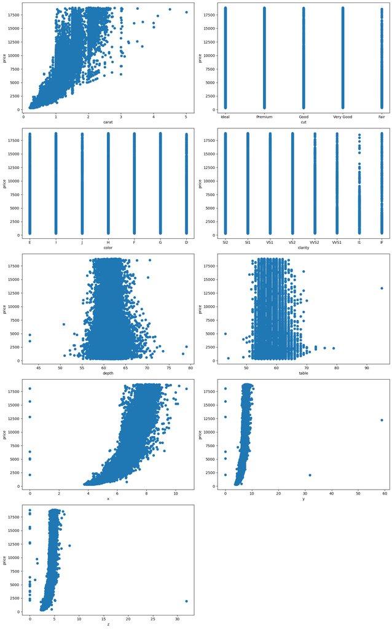

```python
feature_names = ["carat","cut","color","clarity","depth","table","x","y","z"]

# Create subplots
fig, axs = plt.subplots(nrows=5, ncols=2, figsize=(15, 24))

# Flatten the subplot axes
axs = axs.flatten()

# Plot scatter plots
for i, feature in enumerate(feature_names):
        axs[i].scatter(a[feature], a["price"])
        axs[i].set_xlabel(feature)
        axs[i].set_ylabel("price")

# deletes empty subplots
fig.delaxes(axs[-1])

# Adjust spacing between subplots
plt.tight_layout()

# Display the plot
plt.show()
```

### De-noising

x, y and z are lengths so these columns can not have negative values or value = 0.  
Negative values for these columns are most likely to be present because of human error.

```python
noise_indexes = a[((a["x"] <= 0) | (a["y"] <= 0) | (a["z"] <= 0))].index
print(noise_indexes)
a = a.drop(noise_indexes)
print(a.shape)
```

```
Int64Index([ 2046,  4422,  5038,  9370, 10310, 11038, 12568, 14731, 22598,
            22721, 24222, 24336, 25439, 25509, 25726, 45910, 47724],
           dtype='int64')
(49857, 10)
```

Depth is the percentage depth and is dependent on x,y and z as :  
depth = z / mean(x,y)  
out of which neither numerator nor denominator could be negative.  
So depth can't be negative too.

```python
a[a["depth"]<=0]
```

|  | carat | cut | color | clarity | depth | table | price | x | y | z |
| --- | --- | --- | --- | --- | --- | --- | --- | --- | --- | --- |

**depth column dont have any negative values or 0.**

### Removing outliers

**In "carat" Column : the data points are scattered but cant be incuded in the category of outliers.**

**In "cut" "color" and "clarity" Columns : all were categorial data and all categories have good numbers of data points .So they don't have any outliers.**

**In "depth" Column :**

```python
a['depth'].sort_values(ascending=True)
```

```
9567     43.0
4170     43.0
15586    50.8
33846    51.0
44254    52.2
         ...
48120    72.2
49624    72.9
43237    73.6
38838    78.2
48993    79.0
Name: depth, Length: 49857, dtype: float64
```

```python
noise_indexes = a[(a["depth"]<50) | (a["depth"]>80)].index
print(noise_indexes)
a = a.drop(noise_indexes)
```

```
Int64Index([4170, 9567], dtype='int64')
```

**In "table" Column :**

```python
a['table'].sort_values(ascending=True)
```

```
10482    43.0
33051    44.0
21031    49.0
5506     49.0
6824     50.0
         ...
48993    73.0
47617    73.0
47569    76.0
47045    79.0
23104    95.0
Name: table, Length: 49855, dtype: float64
```

```python
noise_indexes = a[(a["table"] < 45) | (a["table"] > 75)].index
print(noise_indexes)
a = a.drop(noise_indexes)
```

```
Int64Index([10482, 23104, 33051, 47045, 47569], dtype='int64')
```

**In "x" Column : data points are scaterred but none of the datapoints are far enough to be considered as outliers**

**In "y" Column : some outliers can be seen in the scatter plot**

```python
a["y"].sort_values(ascending = True)
```

```
29306     3.68
29304     3.71
29302     3.71
29307     3.72
29305     3.73
         ...
24102    10.10
25624    10.16
25426    10.54
45565    31.80
22295    58.90
Name: y, Length: 49850, dtype: float64
```

```python
noise_indexes = a[a["y"] > 11].index
print(noise_indexes)
a = a.drop(noise_indexes)
```

```
Int64Index([22295, 45565], dtype='int64')
```

**In "z" Column : here too there are some outlier**

```python
a["z"].sort_values(ascending = True)
```

```
13506     1.07
20051     1.41
19146     1.53
29299     2.24
43664     2.25
         ...
21909     6.38
25163     6.43
25624     6.72
25426     6.98
44840    31.80
Name: z, Length: 49848, dtype: float64
```

```python
noise_indexes = a[a["z"] > 11].index
print(noise_indexes)
a = a.drop(noise_indexes)
```

```
Int64Index([44840], dtype='int64')
```

### Scatter Plots of Clean and Noiseless data

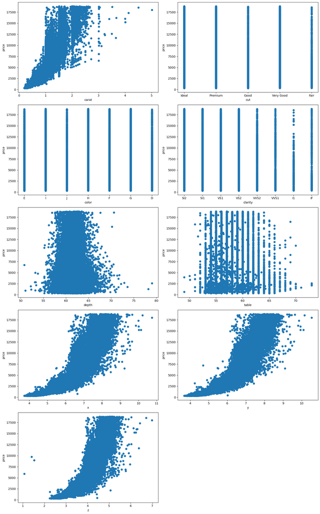

```python
feature_names = ["carat","cut","color","clarity","depth","table","x","y","z"]

# Create subplots
fig, axs = plt.subplots(nrows=5, ncols=2, figsize=(15, 24))

# Flatten the subplot axes
axs = axs.flatten()

# Plot scatter plots
for i, feature in enumerate(feature_names):
        axs[i].scatter(a[feature], a["price"])
        axs[i].set_xlabel(feature)
        axs[i].set_ylabel("price")

# deletes empty subplots
fig.delaxes(axs[-1])

# Adjust spacing between subplots
plt.tight_layout()

# Display the plot
plt.show()
```

### Resetting Index

```python
a = a.reset_index(drop=True)
a
```

|  | carat | cut | color | clarity | depth | table | price | x | y | z |
| --- | --- | --- | --- | --- | --- | --- | --- | --- | --- | --- |
| 0 | 0.23 | Ideal | E | SI2 | 61.5 | 55.0 | 326 | 3.95 | 3.98 | 2.43 |
| 1 | 0.21 | Premium | E | SI1 | 59.8 | 61.0 | 326 | 3.89 | 3.84 | 2.31 |
| 2 | 0.23 | Good | E | VS1 | 56.9 | 65.0 | 327 | 4.05 | 4.07 | 2.31 |
| 3 | 0.29 | Premium | I | VS2 | 62.4 | 58.0 | 334 | 4.20 | 4.23 | 2.63 |
| 4 | 0.31 | Good | J | SI2 | 63.3 | 58.0 | 335 | 4.34 | 4.35 | 2.75 |
| ... | ... | ... | ... | ... | ... | ... | ... | ... | ... | ... |
| 49842 | 0.72 | Ideal | D | SI1 | 60.8 | 57.0 | 2757 | 5.75 | 5.76 | 3.50 |
| 49843 | 0.72 | Good | D | SI1 | 63.1 | 55.0 | 2757 | 5.69 | 5.75 | 3.61 |
| 49844 | 0.70 | Very Good | D | SI1 | 62.8 | 60.0 | 2757 | 5.66 | 5.68 | 3.56 |
| 49845 | 0.86 | Premium | H | SI2 | 61.0 | 58.0 | 2757 | 6.15 | 6.12 | 3.74 |
| 49846 | 0.75 | Ideal | D | SI2 | 62.2 | 55.0 | 2757 | 5.83 | 5.87 | 3.64 |

49847 rows × 10 columns

## Encoding the Categorical Data

**Encoding is needed for "cut", "color" and "clarity" columns for converting categorical data into machine readable data.**

### Label Encoding

```python
data = a
```

```python
cut_mapping = {
    "Fair" : 0,
    "Good" : 1,
    "Very Good" : 2,
    "Premium" : 3,
    "Ideal" : 4,
}

color_mapping = {
    "J" : 0,
    "I" : 1,
    "H" : 2,
    "G" : 3,
    "F" : 4,
    "E" : 5,
    "D" : 6,
}

clarity_mapping = {
    "I1" : 0,
    "SI2" : 1,
    "SI1" : 2,
    "VS2" : 3,
    "VS1" : 4,
    "VVS2" : 5,
    "VVS1" : 6,
    "IF" : 7,
}

label_encoder = LabelEncoder()

# Encode the categorical column using the mapping dictionary
data['cut'] = label_encoder.fit_transform(data['cut'].map(cut_mapping))

data['color'] = label_encoder.fit_transform(data['color'].map(color_mapping))

data['clarity'] = label_encoder.fit_transform(data['clarity'].map(clarity_mapping))

data
```

|  | carat | cut | color | clarity | depth | table | price | x | y | z |
| --- | --- | --- | --- | --- | --- | --- | --- | --- | --- | --- |
| 0 | 0.23 | 4 | 5 | 1 | 61.5 | 55.0 | 326 | 3.95 | 3.98 | 2.43 |
| 1 | 0.21 | 3 | 5 | 2 | 59.8 | 61.0 | 326 | 3.89 | 3.84 | 2.31 |
| 2 | 0.23 | 1 | 5 | 4 | 56.9 | 65.0 | 327 | 4.05 | 4.07 | 2.31 |
| 3 | 0.29 | 3 | 1 | 3 | 62.4 | 58.0 | 334 | 4.20 | 4.23 | 2.63 |
| 4 | 0.31 | 1 | 0 | 1 | 63.3 | 58.0 | 335 | 4.34 | 4.35 | 2.75 |
| ... | ... | ... | ... | ... | ... | ... | ... | ... | ... | ... |
| 49842 | 0.72 | 4 | 6 | 2 | 60.8 | 57.0 | 2757 | 5.75 | 5.76 | 3.50 |
| 49843 | 0.72 | 1 | 6 | 2 | 63.1 | 55.0 | 2757 | 5.69 | 5.75 | 3.61 |
| 49844 | 0.70 | 2 | 6 | 2 | 62.8 | 60.0 | 2757 | 5.66 | 5.68 | 3.56 |
| 49845 | 0.86 | 3 | 2 | 1 | 61.0 | 58.0 | 2757 | 6.15 | 6.12 | 3.74 |
| 49846 | 0.75 | 4 | 6 | 1 | 62.2 | 55.0 | 2757 | 5.83 | 5.87 | 3.64 |

49847 rows × 10 columns

# 5. Splitting the data

#### We cant use whole data for train the model, we also need some part of it in order to test the accuracy of the trained model. so splitting is needed. It is preferred to split data in 70:30 ratio for training and testing purpose respectively.

```python
X = data.drop(["price"],axis=1).values
Y = data['price'].values
```

```python
X_train, X_test, Y_train, Y_test = train_test_split(X, Y, test_size = 0.3, random_state =0)

print("X_train is " ,X_train.shape)
print("X_test is " ,X_test.shape)
print("Y_train is " ,Y_train.shape)
print("Y_test is " ,Y_test.shape)
```

```
X_train is  (34892, 9)
X_test is  (14955, 9)
Y_train is  (34892,)
Y_test is  (14955,)
```

# 6. Training and Prediction

### Linear Regression

```python
# Training the model and fitting the data using linear regression
Lin1 = LinearRegression()
Lin1.fit(X_train, Y_train)
```

```
LinearRegression()
```

```python
# Predicting the values
Y_predicted1 = Lin1.predict(X_test)
```

**Calculating errors and accuracy**

```python
# Calculating Coefficient of determmination or R-squared score
r2 = r2_score(Y_test,Y_predicted1)
print("R-squared score:", r2)
```

```
R-squared score: 0.9074112536494296
```

```python
# Calculate the mean squared error (MSE)
mse = mean_squared_error(Y_test, Y_predicted1)

# Calculate the root mean squared error (RMSE)
rmse = np.sqrt(mse)

print("RMSE:", rmse)
```

```
RMSE: 1211.3854454409961
```

```python
# Calculate the mean absolute error (MAE)
mae = mean_absolute_error(Y_test, Y_predicted1)
print("MAE:", mae)
```

```
MAE: 795.0901304772947
```

```python
# Comparing predicted values with the actual values
diff1 = pd.DataFrame({"Actual_values":Y_test,"Predicted_values":Y_predicted1,"Differences":Y_test-Y_predicted1})
diff1
```

|  | Actual_values | Predicted_values | Differences |
| --- | --- | --- | --- |
| 0 | 4165 | 4661.425658 | -496.425658 |
| 1 | 12209 | 13352.423015 | -1143.423015 |
| 2 | 1624 | 1914.248877 | -290.248877 |
| 3 | 5410 | 6192.187848 | -782.187848 |
| 4 | 2188 | 2954.566270 | -766.566270 |
| ... | ... | ... | ... |
| 14950 | 462 | -323.961421 | 785.961421 |
| 14951 | 1613 | 1909.519789 | -296.519789 |
| 14952 | 7059 | 6284.697889 | 774.302111 |
| 14953 | 693 | -191.182646 | 884.182646 |
| 14954 | 383 | -1097.677965 | 1480.677965 |

14955 rows × 3 columns

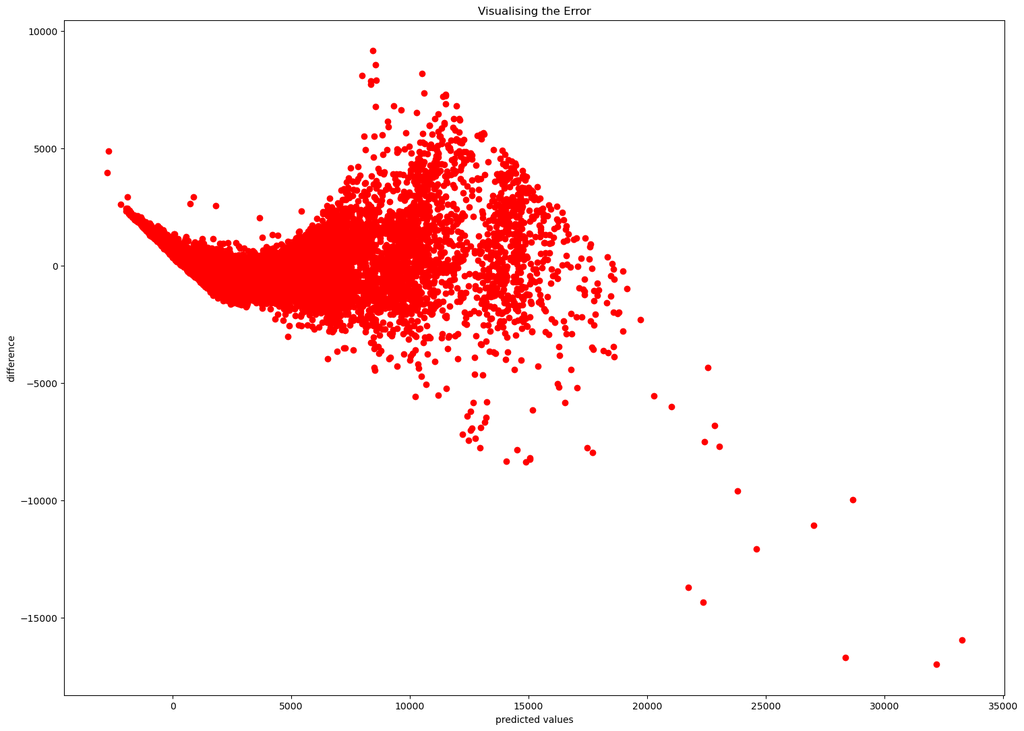

```python
# Plotting the graph between predicted values and Difference(Actual Values - Predicted Values)

plt.figure(figsize = (18, 13))
plt.scatter(Y_predicted1, (Y_test - Y_predicted1), color = "red")
plt.title('Visualising the Error')
plt.xlabel('predicted values')
plt.ylabel('difference')
plt.show()
```

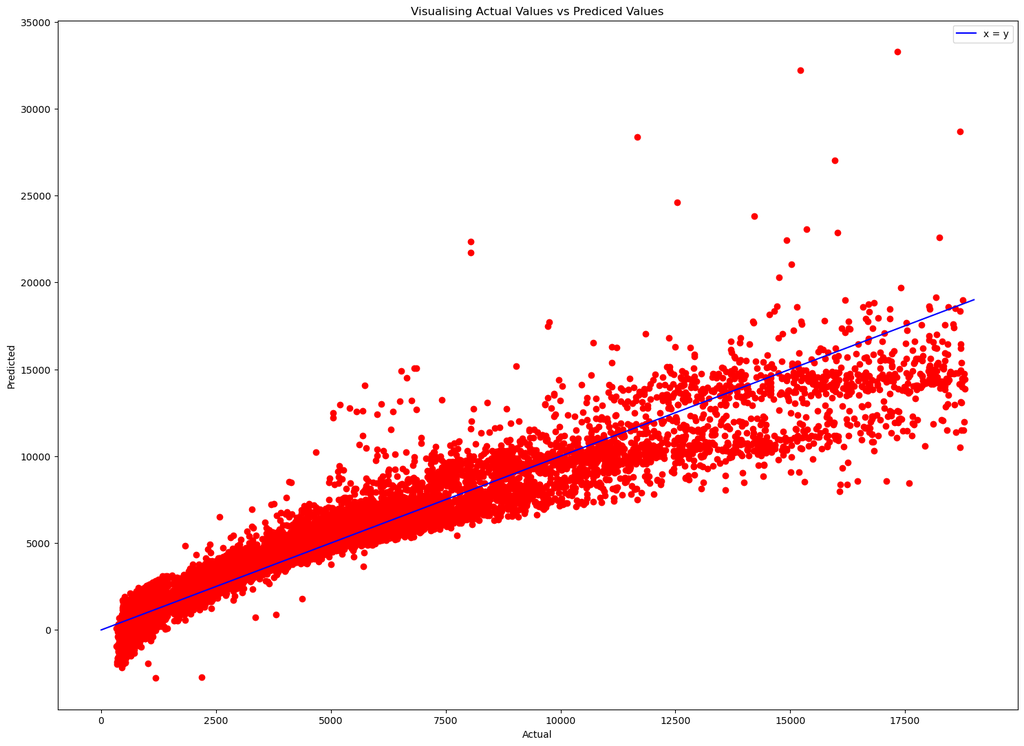

```python
# Plotting the graph between Actual values and Predicted Values

x = [0,19000]
plt.figure(figsize = (18, 13))
plt.scatter(Y_test, Y_predicted1, color = 'red')
plt.plot(x,x, color = 'blue', label = "x = y")
plt.title('Visualising Actual Values vs Prediced Values')
plt.xlabel('Actual')
plt.ylabel('Predicted')
plt.legend()
plt.show()
```

With the above two graphs, it can be observed that though R<sup>2</sup> score is 0.9074112536494296 but still the difference between the actual values and predicted values are huge which can be seen as Root-Mean Square Error = 1211.3854454409961 and Mean Absolute Error = 795.0901304772947 .  
In the second graph, Blue line represents y = x, data points must be scaterred around that equally on both side, which is not the case here, clearly this is not the case of Linear Regression.

### Polynomial Regression

```python
# Training the model and fitting the data using Polynomial features & Linear regression

Poly = PolynomialFeatures(degree=2)
X_poly = Poly.fit_transform(X_train)
Lin2 = LinearRegression()
Lin2.fit(X_poly, Y_train)
```

```
LinearRegression()
```

```python
# predicting the values
Y_predicted2 = Lin2.predict(Poly.fit_transform(X_test))
```

**Calculating errors and accuracy**

```python
# Calculating Coefficient of determmination or R-squared score
r2 = r2_score(Y_test,Y_predicted2)
print("R-squared score:", r2)
```

```
R-squared score: 0.9643562795503912
```

```python
# Calculate the mean squared error (MSE)
mse = mean_squared_error(Y_test, Y_predicted2)

# Calculate the root mean squared error (RMSE)
rmse = np.sqrt(mse)

print("RMSE:", rmse)
```

```
RMSE: 751.6138321413683
```

```python
# Calculate the mean absolute error (MAE)
mae = mean_absolute_error(Y_test, Y_predicted2)

print("MAE:", mae)
```

```
MAE: 447.41703992474095
```

```python
# Comparing predicted values with the actual values
diff2 = pd.DataFrame({"Actual_values":Y_test,"Predicted_values":Y_predicted2,"Differences":Y_test-Y_predicted2})
diff2
```

|  | Actual_values | Predicted_values | Differences |
| --- | --- | --- | --- |
| 0 | 4165 | 4108.460452 | 56.539548 |
| 1 | 12209 | 12312.177972 | -103.177972 |
| 2 | 1624 | 1562.891856 | 61.108144 |
| 3 | 5410 | 5682.043481 | -272.043481 |
| 4 | 2188 | 2379.684929 | -191.684929 |
| ... | ... | ... | ... |
| 14950 | 462 | -204.355936 | 666.355936 |
| 14951 | 1613 | 1631.083285 | -18.083285 |
| 14952 | 7059 | 7184.494562 | -125.494562 |
| 14953 | 693 | 478.770730 | 214.229270 |
| 14954 | 383 | 962.577424 | -579.577424 |

14955 rows × 3 columns

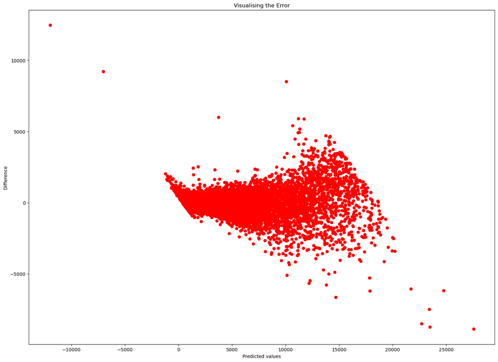

```python
# Plotting the graph between predicted values and Difference(Actual Values - Predicted Values)

plt.figure(figsize = (18, 13))
plt.scatter(Y_predicted2, (Y_test - Y_predicted2), color = "red")
plt.title('Visualising the Error')
plt.xlabel('Predicted values')
plt.ylabel('Difference')
plt.show()
```

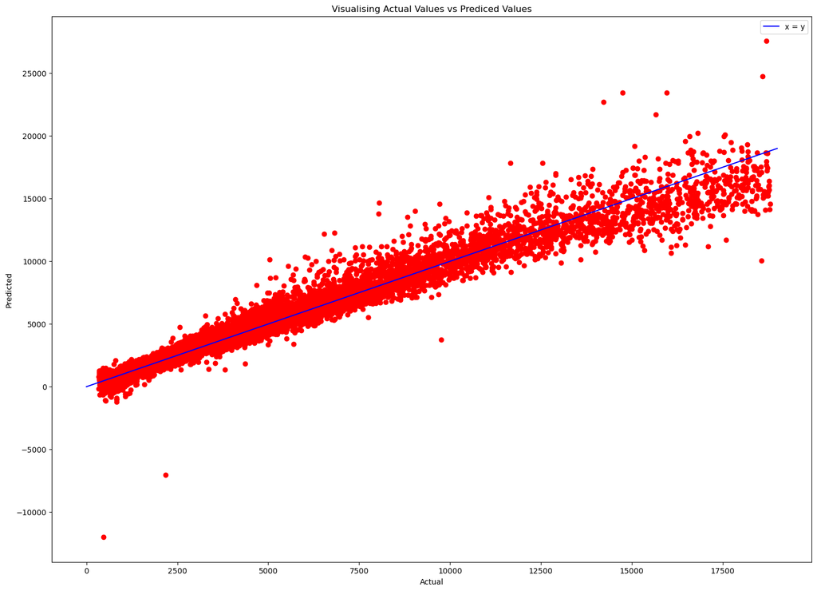

```python
# Plotting the graph between Actual values and Predicted Values

x = [0,19000]
plt.figure(figsize = (18, 13))
plt.scatter(Y_test, Y_predicted2, color = 'red')
plt.plot(x,x, color = 'blue', label = "x = y")
plt.title('Visualising Actual Values vs Prediced Values')
plt.xlabel('Actual')
plt.ylabel('Predicted')
plt.legend()
plt.show()
```

Polynomial Regression with degree = 2 seems to give accurate values for smaller values, but as values increases error also increases. It works far better than linear regression, But it also sometimes predicts -ve prices, which is impossible. And as the values increases the predicted values scatters more and more.  
Here R<sup>2</sup> score is 0.9643562795503912 which is much better than that of linear regression, other than that its Root-Mean Square Error = 751.6138321413683 and Mean Absolute Error = 447.41703992474095 , which are much lesser than those of Linear regression

### K-Nearest Neighbour (KNN) algorithm

```python
# Training the model and fitting the data using K-Nearest Neighbours algorithm

Knn = KNeighborsRegressor(n_neighbors=5)
Knn.fit(X_train, Y_train)
```

```
KNeighborsRegressor()
```

```python
# predicting the results
Y_predicted3 = Knn.predict(X_test)
```

**Calculating errors and accuracy**

```python
# Calculating Coefficient of determmination or R-squared score
r2 = r2_score(Y_test, Y_predicted3)
print("R-squared score:", r2)
```

```
R-squared score: 0.9537434496498972
```

```python
# Calculate the mean squared error (MSE)
mse = mean_squared_error(Y_test, Y_predicted3)

# Calculate the root mean squared error (RMSE)
rmse = np.sqrt(mse)
print("RMSE:", rmse)
```

```
RMSE: 856.2288761546664
```

```python
# Calculate the mean absolute error (MAE)
mae = mean_absolute_error(Y_test, Y_predicted3)
print("MAE:", mae)
```

```
MAE: 467.98613172851884
```

```python
# Comparing predicted values with the actual values
diff3 = pd.DataFrame({"Actual_values":Y_test,"Predicted_values":Y_predicted3,"Differences":Y_test-Y_predicted3})
diff3
```

|  | Actual_values | Predicted_values | Differences |
| --- | --- | --- | --- |
| 0 | 4165 | 3821.6 | 343.4 |
| 1 | 12209 | 12808.6 | -599.6 |
| 2 | 1624 | 1690.8 | -66.8 |
| 3 | 5410 | 5364.0 | 46.0 |
| 4 | 2188 | 2276.0 | -88.0 |
| ... | ... | ... | ... |
| 14950 | 462 | 615.2 | -153.2 |
| 14951 | 1613 | 1644.2 | -31.2 |
| 14952 | 7059 | 6710.4 | 348.6 |
| 14953 | 693 | 708.8 | -15.8 |
| 14954 | 383 | 521.0 | -138.0 |

14955 rows × 3 columns

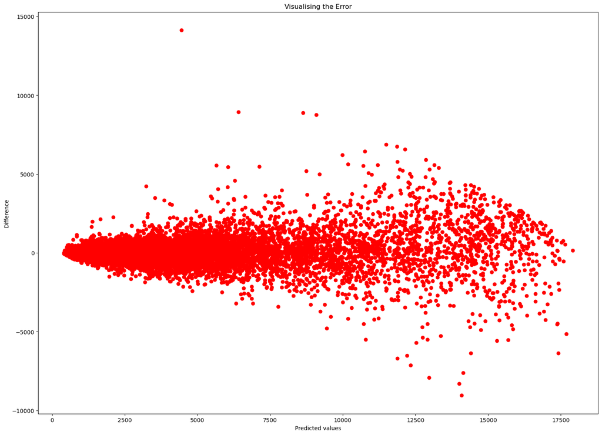

```python
# Plotting the graph between predicted values and Difference(Actual Values - Predicted Values)

plt.figure(figsize = (18, 13))
plt.scatter(Y_predicted3, (Y_test - Y_predicted3), color = "red")
plt.title('Visualising the Error')
plt.xlabel('Predicted values')
plt.ylabel('Difference')
plt.show()
```

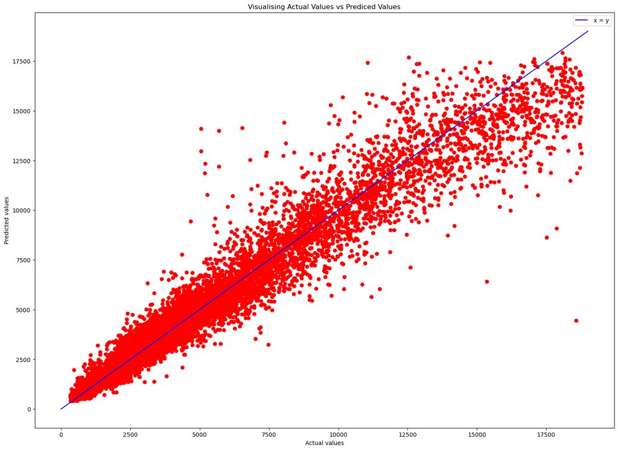

```python
# Plotting the graph between Actual values and Predicted Values

x = [0,19000]
plt.figure(figsize = (18, 13))
plt.scatter(Y_test, Y_predicted3, color = 'red')
plt.plot(x,x, color = 'blue', label = " x = y")
plt.title('Visualising Actual Values vs Prediced Values')
plt.xlabel('Actual values')
plt.ylabel('Predicted values')
plt.legend()
plt.show()
```

### Decision tree

```python
# Training the model and fitting the data using Decision tree algorithm

tree = DecisionTreeRegressor()
tree.fit(X_train, Y_train)
```

```
DecisionTreeRegressor()
```

```python
# Predicting the values
Y_predicted4 = tree.predict(X_test)
```

**Calculating errors and accuracy**

```python
# Calculating Coefficient of determmination or R-squared score
r2 = r2_score(Y_test, Y_predicted4)
print("R-squared score:", r2)
```

```
R-squared score: 0.9642739663259109
```

```python
# Calculate the mean squared error (MSE)
mse = mean_squared_error(Y_test, Y_predicted4)

# Calculate the root mean squared error (RMSE)
rmse = np.sqrt(mse)
print("RMSE:", rmse)
```

```
RMSE: 752.4811950341173
```

```python
# Calculate the mean absolute error (MAE)
mae = mean_absolute_error(Y_test, Y_predicted4)
print("MAE:", mae)
```

```
MAE: 365.7541959210966
```

```python
# Comparing predicted values with the actual values
diff4 = pd.DataFrame({"Actual_values":Y_test,"Predicted_values":Y_predicted4,"Differences":Y_test-Y_predicted4})
diff4
```

|  | Actual_values | Predicted_values | Differences |
| --- | --- | --- | --- |
| 0 | 4165 | 3884.0 | 281.0 |
| 1 | 12209 | 12455.5 | -246.5 |
| 2 | 1624 | 1695.0 | -71.0 |
| 3 | 5410 | 5267.0 | 143.0 |
| 4 | 2188 | 2741.0 | -553.0 |
| ... | ... | ... | ... |
| 14950 | 462 | 447.0 | 15.0 |
| 14951 | 1613 | 2257.0 | -644.0 |
| 14952 | 7059 | 6932.0 | 127.0 |
| 14953 | 693 | 728.0 | -35.0 |
| 14954 | 383 | 393.0 | -10.0 |

14955 rows × 3 columns

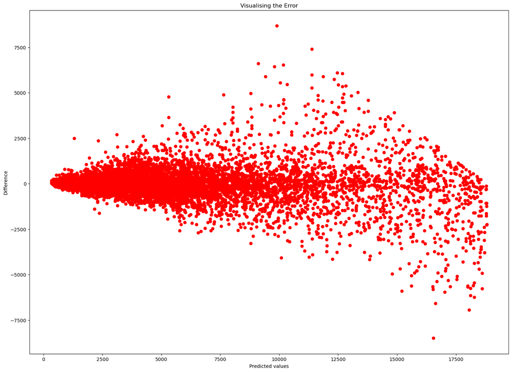

```python
# Plotting the graph between predicted values and Difference(Actual Values - Predicted Values)

plt.figure(figsize = (18, 13))
plt.scatter(Y_predicted4, (Y_test - Y_predicted4), color = "red")
plt.title('Visualising the Error')
plt.xlabel('Predicted values')
plt.ylabel('Difference')
plt.show()
```

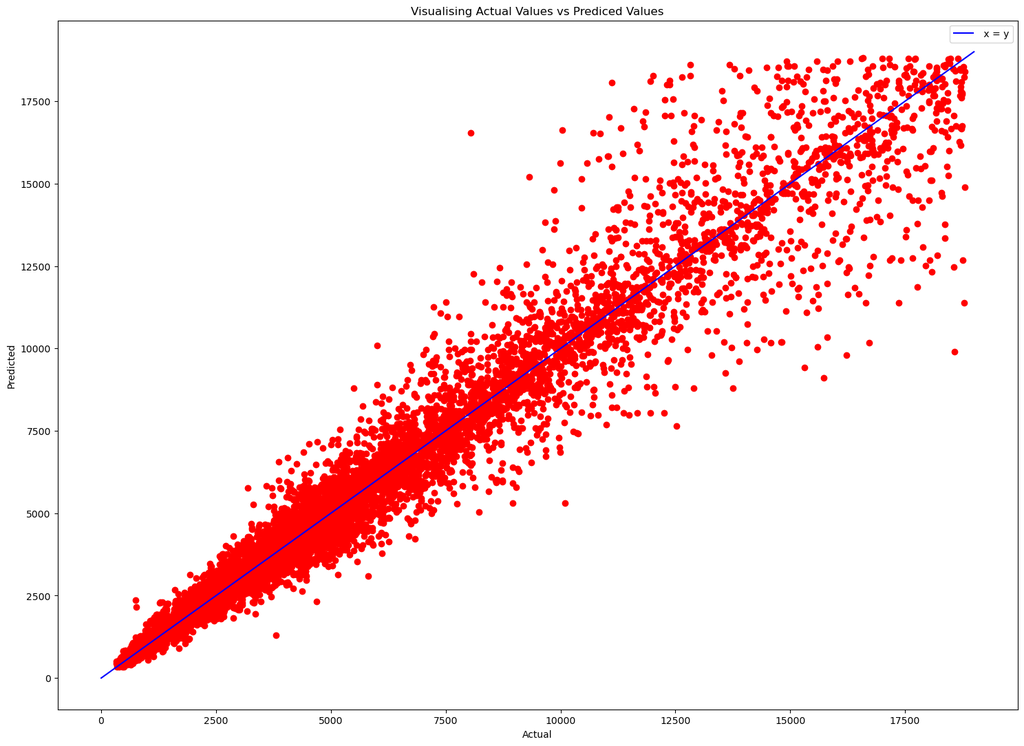

```python
# Plotting the graph between Actual values and Predicted Values

x = [0,19000]
plt.figure(figsize = (18, 13))
plt.scatter(Y_test, Y_predicted4, color = 'red')
plt.plot(x,x, color = 'blue', label = " x = y")
plt.title('Visualising Actual Values vs Prediced Values')
plt.xlabel('Actual')
plt.ylabel('Predicted')
plt.legend()
plt.show()
```

### Random forest

```python
# Training the model and fitting the data using the Random Forest Algorithm

rf = RandomForestRegressor(n_estimators=100, random_state=42)
rf.fit(X_train, Y_train)
```

```
RandomForestRegressor(random_state=42)
```

```python
# Predicting the values
Y_predicted5 = rf.predict(X_test)
```

**Calculating errors and accuracy**

```python
# Calculating Coefficient of determmination or R-squared score
r2 = r2_score(Y_test, Y_predicted5)
print("R-squared score:", r2)
```

```
R-squared score: 0.9812487950408243
```

```python
# Calculate the mean squared error (MSE)
mse = mean_squared_error(Y_test, Y_predicted5)

# Calculate the root mean squared error (RMSE)
rmse = np.sqrt(mse)
print("RMSE:", rmse)
```

```
RMSE: 545.1522889779909
```

```python
# Calculate the mean absolute error (MAE)
mae = mean_absolute_error(Y_test, Y_predicted5)
print("MAE:", mae)
```

```
MAE: 269.04833976373567
```

```python
# Comparing predicted values with the actual values
diff5 = pd.DataFrame({"Actual_values":Y_test,"Predicted_values":Y_predicted3,"Differences":Y_test-Y_predicted3})
diff5
```

|  | Actual_values | Predicted_values | Differences |
| --- | --- | --- | --- |
| 0 | 4165 | 3821.6 | 343.4 |
| 1 | 12209 | 12808.6 | -599.6 |
| 2 | 1624 | 1690.8 | -66.8 |
| 3 | 5410 | 5364.0 | 46.0 |
| 4 | 2188 | 2276.0 | -88.0 |
| ... | ... | ... | ... |
| 14950 | 462 | 615.2 | -153.2 |
| 14951 | 1613 | 1644.2 | -31.2 |
| 14952 | 7059 | 6710.4 | 348.6 |
| 14953 | 693 | 708.8 | -15.8 |
| 14954 | 383 | 521.0 | -138.0 |

14955 rows × 3 columns

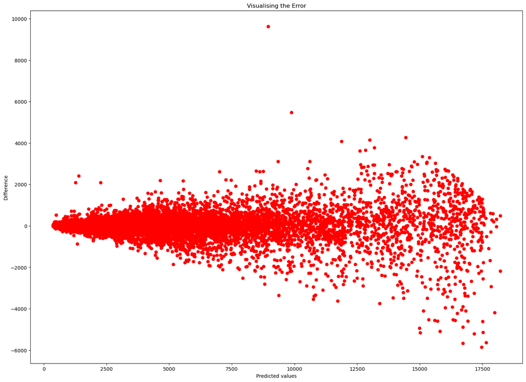

```python
# Plotting the graph between predicted values and Difference(Actual Values - Predicted Values)

plt.figure(figsize = (18, 13))
plt.scatter(Y_predicted5, (Y_test - Y_predicted5), color = "red")
plt.title('Visualising the Error')
plt.xlabel('Predicted values')
plt.ylabel('Difference')
plt.show()
```

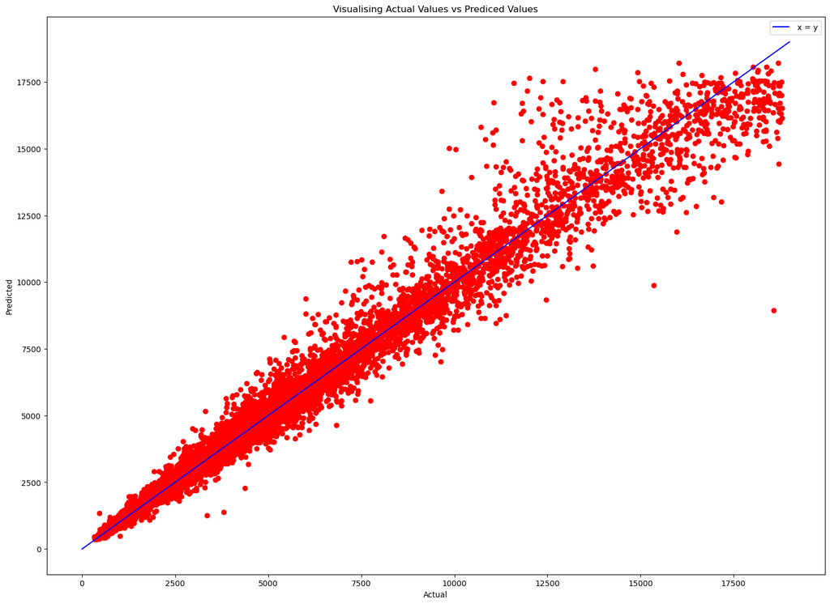

```python
# Plotting the graph between Actual values and Predicted Values

x = [0,19000]
plt.figure(figsize = (18, 13))
plt.scatter(Y_test, Y_predicted5, color = 'red')
plt.plot(x,x, color = 'blue', label = " x = y")
plt.title('Visualising Actual Values vs Prediced Values')
plt.xlabel('Actual')
plt.ylabel('Predicted')
plt.legend()
plt.show()
```

**While using Random Forest algorithm, we get R<sup>2</sup> score as 0.9812487950408243 which is highest yet for this dataset. Its Root-Mean Square Error = 545.1522889779909 and Mean Absolute Error = 269.04833976373567 , which is again least among those by any other prediction algorithm. There are no negative predictions in this model, so it is more reliable.**